# Concurrent IBE and IBR in terradish

Bill Peterman

## 1 What are IBE and IBR, and why fit them together?

Landscape geneticists commonly ask: why are some pairs of populations more genetically different than others? Two broad classes of explanation exist:

- **Isolation by resistance (IBR):** genetic differentiation is associated with resistance distance derived from a covariate-parameterized conductance graph.
- **Isolation by environment (IBE):** genetic differentiation is associated with environmental dissimilarity between sampled sites.

Both associations can occur at the same time and can be confounded. Fitting IBE and IBR terms **concurrently** estimates each coefficient conditional on the other term and the MLPE dependence structure. It does not causally allocate variation to distinct biological processes.

### 1.1 Where each process lives in the model

`terradish` places the two terms in different parts of one measurement model:

```
                           CONDUCTANCE SIDE
  Raster covariates   -->  loglinear_conductance  -->  resistance distances
  (altitude, forest)         theta parameters               R_ij

                           MEASUREMENT SIDE
  R_ij + endpoint          mlpe_covariates()      -->  genetic distances
  differences (Z_ij)       beta, gamma, rho_MLPE        S_ij
```

The mean structure of the joint model is:

$$S_{ij} = α + β · R_{ij} + Z_{ij} · γ +
e_{ij}$$

where:

- $R_{ij}$ is the pairwise resistance distance (determined by the conductance surface and the θ parameters).
- $Z_{ij}$ is a pairwise endpoint-difference covariate (some measure of how environmentally dissimilar sites *i* and *j* are).
- $β$ describes the conditional IBR association: does resistance distance predict genetic differentiation after accounting for environment?
- **γ** describes the conditional IBE association: does environmental mismatch predict genetic differentiation after accounting for landscape resistance?
- $e_{ij}$ is a residual following the MLPE correlation structure (see `vignette("getting-started", package = "terradish")`).

## 2 Prerequisites

This vignette assumes familiarity with the basic `terradish` workflow. If you have not yet read `vignette("getting-started", package = "terradish")`, start there.

## 3 Set up: data and scaled covariates

```r
library(terradish)
library(terra)

data(melip)
melip.altitude    <- terra::unwrap(melip.altitude)
melip.forestcover <- terra::unwrap(melip.forestcover)
melip.coords      <- terra::unwrap(melip.coords)

# Scale continuous covariates before building the conductance surface.
# This keeps the conductance parameters on a comparable scale and avoids
# numerical overflow in exp(theta * x).
covariates <- c(melip.altitude, melip.forestcover)
names(covariates) <- c("altitude", "forestcover")
covariates <- scale_covariates(covariates)

surface <- conductance_surface(covariates, melip.coords, directions = 8)
```

## 4 Step 1: Construct IBE covariates

IBE operates at the level of pairs of sites. For each pair (i, j) we need a number that quantifies how environmentally different those two sites are. The helper `pairwise_endpoint_covariates()` computes this from site-level environmental values.

```r
ibe_altitude <- melip.altitude
names(ibe_altitude) <- "altitude_site"

z_ibe <- pairwise_endpoint_covariates(
  ibe_altitude,            # site-level environmental data (raster or matrix)
  coords    = melip.coords,# focal-point locations (used to extract from raster)
  transform = "absdiff",  # how to convert site values into pairwise values
  scale     = TRUE         # standardize site values first
)

# Each row is one pair of sites; each column is one pairwise covariate.
dim(z_ibe)
```

```
#> [1] 666   1
```

```r
head(z_ibe)
```

```
#>      absdiff_altitude_site
#> [1,]             0.5217511
#> [2,]             1.6264202
#> [3,]             0.6761406
#> [4,]             0.1773603
#> [5,]             1.1508445
#> [6,]             0.4351686
```

### 4.1 Choosing a pairwise transform

Four transforms are available:

| Transform | Formula | When to use |
| --- | --- | --- |
| `"absdiff"` | \|x_i − x_j\| | One covariate; symmetric, intuitive |
| `"sqdiff"` | (x_i − x_j)² | Penalizes large differences more; useful with noisy data |
| `"euclidean"` | √Σ(x_ik − x_jk)² | Multivariate environment; collapses to a single distance |
| `"manhattan"` | Σ\|x_ik − x_jk\| | Multivariate environment; less sensitive to outlier dimensions |

Use `"absdiff"` (the default) for a single continuous covariate. For a multivariate environment (e.g. altitude + precipitation + temperature combined), `"euclidean"` or `"manhattan"` produce a single distance column that is easier to interpret and avoid inflating the model with many correlated predictors.

For two or more covariates treated separately, `"absdiff"` or `"sqdiff"` return one column per covariate:

```r
# Example: separate absolute differences for altitude and forest cover
z_multi <- pairwise_endpoint_covariates(
  covariates,            # the two-layer scaled raster stack
  coords    = melip.coords,
  transform = "absdiff",
  scale     = FALSE      # already scaled in the raster
)
dim(z_multi)   # one column per layer
```

```
#> [1] 666   2
```

```r
colnames(z_multi)
```

```
#> [1] "absdiff_altitude"    "absdiff_forestcover"
```

For this vignette we use altitude only (`z_ibe`) to keep the IBE side simple and interpretable.

## 5 Step 2: Build the joint measurement model

`mlpe_covariates()` wraps the pairwise covariates into an MLPE measurement model. The resulting object (`g_ibe`) can be passed anywhere that `mlpe` can: `terradish()`, `terradish_grid()`, and `terradish_cv()`.

```r
g_ibe <- mlpe_covariates(z_ibe)
```

`g_ibe` is a function, not a fitted model; it defines the likelihood structure. The actual parameters (β, γ, and the MLPE correlation) are estimated when you call `terradish()`.

## 6 Step 3: Fit the four candidate models

To compare conditional support for IBR and IBE terms, fit all four combinations. These models do not uniquely attribute genetic structure to either process.

```r
# NewtonRaphsonControl limits the number of optimizer iterations.
# The vignette caps maxit at 20. In an applied analysis, allow convergence and
# verify optimizer diagnostics rather than relying on this illustrative cap.
ctrl <- NewtonRaphsonControl(maxit = 20, verbose = FALSE)

# IBD: null model, no landscape or environment predictors
fit_ibd <- terradish(
  melip.Fst ~ 1,
  data              = surface,
  conductance_model = loglinear_conductance,
  measurement_model = mlpe,
  leverage          = FALSE,
  control           = ctrl
)

# IBE only: environmental mismatch, but no landscape resistance
fit_ibe <- terradish(
  melip.Fst ~ 1,           # no raster covariates on the conductance side
  data              = surface,
  conductance_model = loglinear_conductance,
  measurement_model = g_ibe, # IBE is on the measurement side
  leverage          = FALSE,
  control           = ctrl
)

# IBR only: landscape resistance, no environmental mismatch
fit_ibr <- terradish(
  melip.Fst ~ altitude + forestcover,
  data              = surface,
  conductance_model = loglinear_conductance,
  measurement_model = mlpe,
  leverage          = FALSE,
  control           = ctrl
)

# Joint IBE + IBR: both processes in a single model
fit_joint <- terradish(
  melip.Fst ~ altitude + forestcover,
  data              = surface,
  conductance_model = loglinear_conductance,
  measurement_model = g_ibe,
  leverage          = FALSE,
  control           = ctrl
)
```

> **Note on `leverage = FALSE`:** By default, `terradish()` computes influence/leverage diagnostics for each observation, which requires additional linear-algebra work. Setting `leverage = FALSE` skips this step to reduce run time. For a final analysis where you want diagnostics, set this argument to `TRUE`.

## 7 Step 4: Interpret the joint model

### 7.1 Conductance parameters (theta)

`coef()` returns the θ values that map raster covariates to fitted relative conductance:

```r
coef(fit_ibr)   # IBR-only model
```

```
#>    altitude forestcover
#> -0.49818394  0.08470684
```

```r
coef(fit_joint) # joint model (theta side only)
```

```
#>    altitude forestcover
#>  -0.5196237   0.1431812
```

Interpretation is the same as in any IBR model: a positive θ means higher covariate values are associated with higher fitted relative conductance, conditional on the other terms and graph; a negative θ means lower fitted relative conductance. These coefficients do not directly measure movement, permeability, or a causal barrier. See `vignette("getting-started", package = "terradish")` for conductance ratios.

Notice that the θ estimates may shift between `fit_ibr` and `fit_joint`. That is expected: when the joint model can attribute some of the pairwise variation to environmental mismatch (γ), it no longer needs the IBR coefficients to carry that variation.

### 7.2 IBE coefficients (gamma, inside phi)

Because IBE lives in the measurement model rather than the conductance model, its coefficient (γ) is reported inside `phi`, the vector of nuisance parameters:

```r
summary(fit_joint)
```

```
#> Conductance surface with 22443 vertices (37 focal) estimated by maximum likelihood
#> Call:   terradish(formula = melip.Fst ~ altitude + forestcover, data = surface,
#>     conductance_model = loglinear_conductance, measurement_model = g_ibe,
#>     leverage = FALSE, control = ctrl)
#>
#> Loglikelihood: 2211.976 (7 degrees freedom)
#> AIC: -4409.951
#>
#> Number of function calls: 17
#> Number of optimization steps: 5
#> Norm of gradient at MLE: 2.705922e-09
#>
#> Nuisance parameters (conditional on fitted conductance surface; measurement-model scale):
#>                        Estimate   Std. Error  Lower 95%  Upper 95%
#> alpha                  -0.043598   0.010994   -0.065146  -0.022050
#> beta                    0.321238   0.009160    0.303284   0.339192
#> absdiff_altitude_site   0.013110   0.001166    0.010824   0.015395
#> tau                     6.052252   0.199821    5.660610   6.443893
#> rho                     1.671649   0.244222    1.192982   2.150316
#>
#> Coefficients:
#>             Estimate Std. Error z value Pr(>|z|)
#> altitude     -0.5196     0.0708   -7.34 2.14e-13 ***
#> forestcover   0.1432     0.1046    1.37    0.171
#> ---
#> Signif. codes:  0 '***' 0.001 '**' 0.01 '*' 0.05 '.' 0.1 ' ' 1
#>
#> Correlation of Coefficients:
#>              altitude
#> forestcover 0.5705743
```

Look for the row named `absdiff_<layer>_site` in the phi table. A positive γ means that sites with greater altitude differences are more genetically different, after accounting for the resistance distance between them. A negative γ (rarely biologically expected for IBE) would mean the opposite.

The summary table also reports confidence intervals for the nuisance parameters, including the IBE coefficient. These intervals are conditional on the fitted conductance surface, so they should be interpreted as uncertainty in the MLPE regression layer after the IBR surface has been estimated.

```r
summary(fit_joint)$phi_table["absdiff_altitude_site", ]
```

```
#>    Estimate  Std. Error   Lower 95%   Upper 95%
#> 0.013109805 0.001166119 0.010824254 0.015395356
```

Because γ is on the response scale, it is often easier to interpret as the expected change in genetic distance across a meaningful change in the pairwise covariate. `mlpe_response_change()` does this calculation using the pairwise covariates stored in the fitted measurement model. By default, it compares the 90th and 10th percentiles:

```r
mlpe_response_change(fit_joint)
```

```
#>               covariate        low     high contrast   estimate   conf.low
#> 1 absdiff_altitude_site 0.08887153 2.336687 2.247815 0.02946842 0.02433092
#>    conf.high conf.level
#> 1 0.03460591       0.95
```

The `estimate` column is the expected change in pairwise genetic distance over that covariate contrast, after accounting for the fitted resistance distance. For a custom contrast, provide explicit low and high values:

```r
mlpe_response_change(fit_joint,
                     covariate = "absdiff_altitude_site",
                     values = c(0, 2))
```

```
#>               covariate low high contrast   estimate   conf.low  conf.high
#> 1 absdiff_altitude_site   0    2        2 0.02621961 0.02164851 0.03079071
#>   conf.level
#> 1       0.95
```

The other phi parameters (`alpha`, `beta`, `tau`, `rho`) are the same as in a plain `mlpe` fit: intercept, IBR slope, log precision, and an unconstrained correlation parameter. Transform the last two to residual precision with `exp(tau)` and to the shared-site correlation with `plogis(rho) / 2`.

### 7.3 Quick summary of which parameter lives where

| Parameter | Symbol | Where it appears | What it measures |
| --- | --- | --- | --- |
| Conductance | θ | `coef(fit)` | Conditional association between raster covariates and fitted relative conductance |
| IBR slope | β (`beta`) | `summary(fit)$phi` | How resistance distance predicts genetic distance |
| IBE slope | γ (`absdiff_*_site`) | `summary(fit)$phi` | How environmental mismatch predicts genetic distance |
| IBE response change | γ ΔZ | `mlpe_response_change(fit)` | Expected genetic-distance change across a pairwise-covariate contrast |
| Intercept | α (`alpha`) | `summary(fit)$phi` | Baseline genetic distance at zero resistance |
| Residual precision | exp(τ) (`tau`) | `summary(fit)$phi` | Inverse residual variance |
| MLPE correlation | plogis(ρ)/2 (`rho`) | `summary(fit)$phi` | Shared-site correlation in pairwise residuals |

## 8 Step 5: Compare the model set

### 8.1 Information criteria

`aic_table()` ranks these four models because they use the same response, sites, graph domain, Gaussian likelihood family, and full pair set:

```r
aic_table(
  list(fit_ibd, fit_ibe, fit_ibr, fit_joint),
  mod_names = c("IBD", "IBE only", "IBR only", "IBE + IBR (joint)")
)
```

```
#>               model K       AIC Delta_AIC AIC_wt Cum.wt   loglik
#> 4 IBE + IBR (joint) 7 -4409.951    0.0000      1      1 2211.976
#> 3          IBR only 6 -4298.770  111.1816      0      1 2155.385
#> 2          IBE only 5 -4291.688  118.2635      0      1 2150.844
#> 1               IBD 4 -4174.217  235.7348      0      1 2091.108
```

A lower AIC indicates a better balance of fit and parsimony. The delta column shows how far each model is from the best. Models within 2 AIC units of the best are generally considered to have comparable support.

Use AICc when the number of sampling sites is modest relative to the number of parameters:

```r
aic_table(
  list(fit_ibd, fit_ibe, fit_ibr, fit_joint),
  mod_names = c("IBD", "IBE only", "IBR only", "IBE + IBR (joint)"),
  AICc = TRUE
)
```

```
#>               model K       AIC      AICc Delta_AICc AICc_wt Cum.wt   loglik
#> 4 IBE + IBR (joint) 7 -4409.951 -4406.089     0.0000       1      1 2211.976
#> 3          IBR only 6 -4298.770 -4295.970   110.1195       0      1 2155.385
#> 2          IBE only 5 -4291.688 -4289.752   116.3369       0      1 2150.844
#> 1               IBD 4 -4174.217 -4172.967   233.1228       0      1 2091.108
```

### 8.2 Likelihood ratio tests for nested comparisons

Within the IBR family (models with a conductance surface), nested models can be tested with `anova()`:

```r
# Does the joint model improve on IBR-only?
anova(fit_joint, fit_ibr)
```

```
#> Likelihood ratio test
#> Null: ~ altitude + forestcover
#> Alt: ~ altitude + forestcover
#>      logLik Df  ChiSq Df(ChiSq)  Pr(>Chi)
#> Null 2155.4  6
#> Alt  2212.0  7 113.18         1 < 2.2e-16 ***
#> ---
#> Signif. codes:  0 '***' 0.001 '**' 0.01 '*' 0.05 '.' 0.1 ' ' 1
```

```r
# Does IBR-only improve on IBD?
anova(fit_ibr, fit_ibd)
```

```
#> Likelihood ratio test
#> Null: ~ 1
#> Alt: ~ altitude + forestcover
#>      logLik Df  ChiSq Df(ChiSq)  Pr(>Chi)
#> Null 2091.1  4
#> Alt  2155.4  6 128.55         2 < 2.2e-16 ***
#> ---
#> Signif. codes:  0 '***' 0.001 '**' 0.01 '*' 0.05 '.' 0.1 ' ' 1
```

Note that IBE-only (`fit_ibe`) and IBR-only (`fit_ibr`) are **not** nested in each other; they differ on which side of the model (conductance vs. measurement) carries the predictors. Use `aic_table()`, not `anova()`, to compare them.

### 8.3 Cross-validation for predictive comparison

`cv_model_selection()` combines held-out log-likelihoods with an AIC table so you can compare models on both in-sample fit and out-of-sample prediction.

`terradish_cv()` requires at least one conductance parameter, so this helper can be called for the IBR-only and joint models. The IBD and IBE-only models use `~ 1` and are not evaluated by this workflow. Do not substitute in-sample log-likelihood for held-out likelihood; those quantities are not comparable.

```r
cv_ctrl <- NewtonRaphsonControl(maxit = 15, verbose = FALSE)

# IBR-only: has conductance parameters, so held-out evaluation is supported
cv_ibr <- terradish_cv(
  pts = melip.coords, covariates = covariates,
  fmla = melip.Fst ~ altitude + forestcover, model = mlpe,
  prop_train = 2 / 3, seed = 1, fit_full = TRUE,
  control = cv_ctrl
)

# Joint IBE + IBR: uses the same held-out split
cv_joint <- terradish_cv(
  pts = melip.coords, covariates = covariates,
  fmla = melip.Fst ~ altitude + forestcover, model = g_ibe,
  prop_train = 2 / 3, seed = 1, fit_full = TRUE,
  control = cv_ctrl
)

# Compare only models evaluated on held-out data from the same split.
comparison <- cv_model_selection(
  list(
    list(train_mod = cv_ibr$train_mod,
         cv_loglik  = cv_ibr$cv_loglik,
         full_mod   = cv_ibr$full_mod),
    list(train_mod = cv_joint$train_mod,
         cv_loglik  = cv_joint$cv_loglik,
         full_mod   = cv_joint$full_mod)
  ),
  cv_names = c("IBR only", "IBE + IBR (joint)"),
  aic = TRUE
)

# Held-out log-likelihood (higher is better predictive performance)
comparison$loglik_tab
```

```
#>               model K   loglik  Delta_LL
#> 2 IBE + IBR (joint) 7 219.7550  0.000000
#> 1          IBR only 6 215.5317 -4.223335
```

```r
# AIC table from the full-data fits
comparison$AIC_tab
```

```
#>                             model K       AIC Delta_AIC AIC_wt Cum.wt   loglik
#> 2 altitude + forestcover [mlpe:1] 7 -4409.951    0.0000      1      1 2211.976
#> 1          altitude + forestcover 6 -4298.770  111.1816      0      1 2155.385
```

> **Why cross-validate?** AIC summarizes in-sample likelihood with a complexity penalty. Cross-validation evaluates held-out predictive likelihood. Random site splits can leak information across spatial clusters, so use folds aligned with the intended prediction target when transfer to new regions or clusters is the goal.

For a more stable estimate of predictive performance, repeat across multiple random splits using `terradish_cv_replicates()`:

```r
cv_joint_reps <- terradish_cv_replicates(
  pts        = melip.coords,
  covariates = covariates,
  fmla       = melip.Fst ~ altitude + forestcover,
  model      = g_ibe,
  seeds      = 1:5,
  fit_full   = FALSE,
  keep_fits  = FALSE,
  control    = cv_ctrl
)

summary(cv_joint_reps)
```

```
#> Repeated terradish cross-validation summary
#> Replicates: 5
#> Mean held-out loglikelihood: 95.44
#> SD held-out loglikelihood: 11.58
#> Range: 79.8 to 110.7
#>
#> $replicate
#> [1] 1 2 3 4 5
#>
#> $seed
#> [1] 1 2 3 4 5
#>
#> $cv_loglik
#> [1] 110.68320  79.79821 100.17758  96.97502  89.55687
#>
#> attr(,"class")
#> [1] "data.frame"
```

## 9 Step 6: Visualize the joint model

### 9.1 Observed vs. fitted genetic distances

`plot(fit, type = "fit")` shows the pairwise genetic distances against the resistance distances implied by the fitted model, with a least-squares regression line:

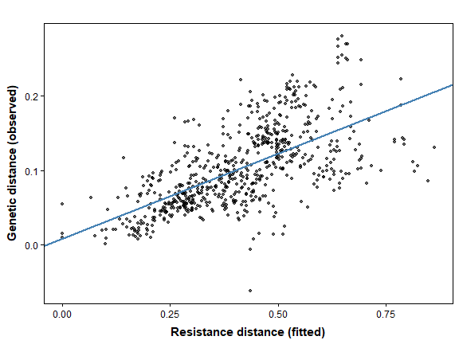

*Observed vs. fitted pairwise genetic distances from the joint model.*

```r
plot(fit_joint, type = "fit")
```

### 9.2 Fitted conductance surface

The conductance surface reflects the θ side of the model, estimated jointly with the IBE term. `plot(fit, type = "surface", data = surface)` shows the point estimate and 95% confidence interval bounds in a single three-panel figure:

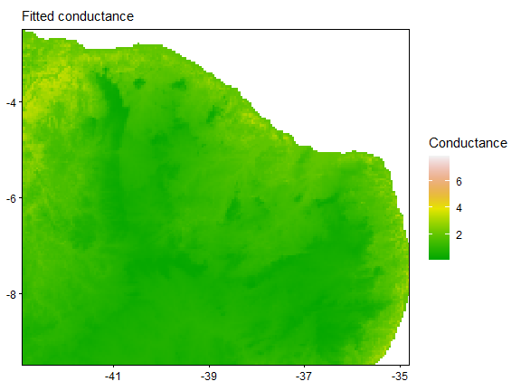

*Estimated conductance surface from the joint IBE + IBR model.*

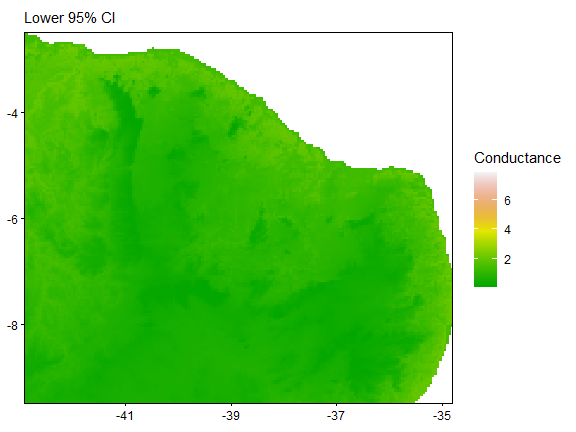

*Estimated conductance surface from the joint IBE + IBR model.*

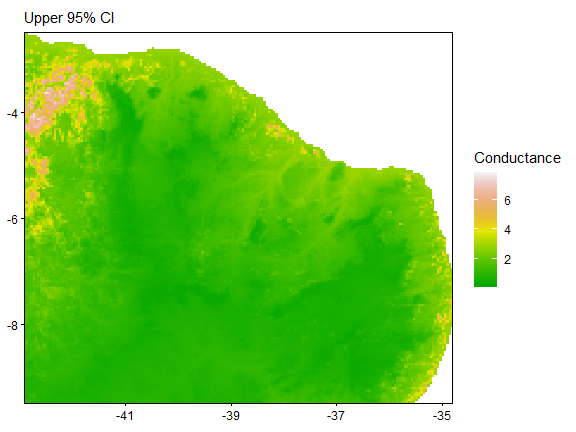

*Estimated conductance surface from the joint IBE + IBR model.*

```r
plot(fit_joint, type = "surface", data = surface)
```

### 9.3 Marginal associations of landscape covariates

`plot(fit, type = "marginal", data = surface)` illustrates the conditional association between each raster covariate and fitted conductance after accounting for the other terms. Because we used `scale_covariates()`, x-axes are back-transformed to the original units automatically:

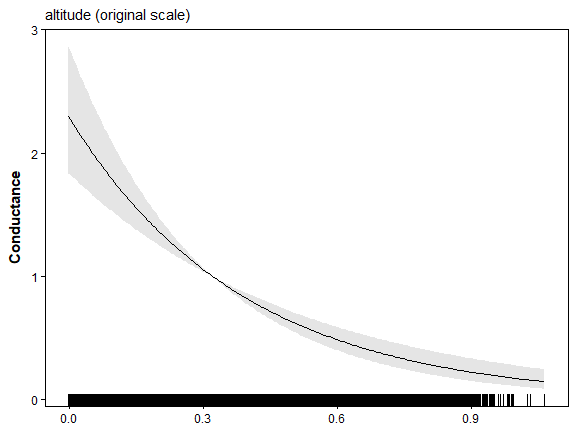

*Marginal conductance associations for the joint IBE + IBR model.*

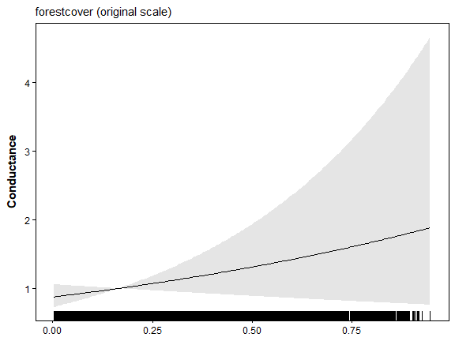

*Marginal conductance associations for the joint IBE + IBR model.*

```r
plot(fit_joint, type = "marginal", data = surface)
```

Compare these curves with the IBR-only model to see how adding the IBE term changes fitted relative conductance:

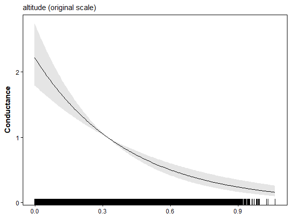

*Marginal conductance associations for the IBR-only model.*

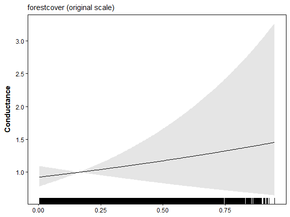

*Marginal conductance associations for the IBR-only model.*

```r
plot(fit_ibr, type = "marginal", data = surface)
```

### 9.4 Constraining inference to focal support

If a covariate tail is weakly represented at focal sites, use focal-support clamping to stabilize interpretation:

```r
plot(
  fit_joint,
  type = "marginal",
  data = surface,
  support = "focal",
  support_probs = c(0.01, 0.99),
  clamp_covariates = c("altitude", "forestcover")
)

cond_joint_focal <- conductance(
  surface,
  fit_joint,
  support = "focal",
  support_probs = c(0.01, 0.99),
  clamp_covariates = c("altitude", "forestcover")
)
```

## 10 Step 7: Saved-results utilities

Some workflows fit `terradish` models once, save them to disk, and later extract summaries. Two helpers support this pattern.

`terradish_results()` inspects a terradish-style results directory and recovers the fitted objects and metadata stored there:

```r
# Create a temporary directory to illustrate the pattern.
tmp_dir <- tempfile("terradish-results-")
dir.create(tmp_dir)

# Save the joint fit and a minimal AllResults object.
saveRDS(fit_joint, file.path(tmp_dir, "fit--mlpe.rds"))
saveRDS(
  list(
    effect_size = coef(fit_joint),
    pts         = melip.coords,
    covariates  = covariates
  ),
  file.path(tmp_dir, "AllResults_list.rds")
)

results_info <- terradish_results(tmp_dir)
names(results_info)
```

```
#> [1] "all_results" "all_dirs"    "pts"         "covariates"  "effect_size"
```

`terradish_parameters()` extracts a compact coefficient table from a saved fitted model. This is useful in simulation studies where you want to compare generating coefficients with estimated values across many saved runs:

```r
parameter_table <- terradish_parameters(
  tmp_dir,
  model      = "mlpe",
  save_table = FALSE
)

parameter_table
```

```
#>               parameter   true_eff    est_eff     est_SE
#> altitude       altitude -0.5196237 -0.5196237 0.07079784
#> forestcover forestcover  0.1431812  0.1431812 0.10454990
```

## 11 Alternative approach: Wishart-based IBE with `wishart_covariates()`

The `mlpe_covariates()` approach in Steps 1-7 adds environmental terms to the **mean structure** of an MLPE regression. A conceptually different route adds environmental information to the **covariance structure** of a Wishart likelihood model. Use this alternative when:

- You are using `generalized_wishart` (an admissible squared-distance response with known effective `nu`) or `wishart_covariance` (a positive semidefinite covariance-matrix response).
- You have a known effective marker degrees-of-freedom value (`nu`) to supply as the Wishart degrees-of-freedom parameter.
- The response is admissible for the chosen Wishart representation and you want a full-matrix covariance-kernel likelihood rather than an MLPE mean regression.

`wishart_covariates()` is the direct Wishart analogue of `mlpe_covariates()`. Instead of adding pairwise environmental dissimilarities as regression covariates, it builds an outer-product kernel ${K_k = z_k z_k^\top}$ for each site-level environmental covariate and adds it to the fitted covariance matrix:

$$\Sigma = \tau E(\theta) + \sum_k
\lambda_k K_k + \exp(\sigma) I$$

Do not use `pair_subset_measurement_model()` for this workflow. That helper selects pair rows for distance-regression models such as `leastsquares` and `mlpe`. Wishart models evaluate the full response matrix likelihood, so the environmental term needs to enter as a full site-by-site kernel through `wishart_covariates()`.

A positive ${\lambda_k}$ adds positive covariance along the specified environmental kernel after the graph covariance. This kernel weight is not numerically comparable to the MLPE slope ${\gamma}$ and does not establish a causal environmental process.

### 11.1 Building the Wishart IBE measurement model

The code below constructs an admissible squared-distance response from a simulated positive semidefinite covariance matrix, then shows the `generalized_wishart` API. For real data, being labeled a distance matrix is not sufficient. Establish that the response is admissible for the centered covariance representation, or use `"wishart_covariance"` with a positive semidefinite covariance matrix from `cov_from_genetic_data()`.

```r
nu_demo <- 50
sim_wishart <- simulate_covariance_response(
  theta   = c(altitude = 0.35, forestcover = -0.25),
  formula = ~ altitude + forestcover,
  data    = surface,
  tau     = 0.8,
  sigma   = 0.2,
  nu      = nu_demo,
  seed    = 2026
)
S_wishart <- dist_from_cov(sim_wishart$covariance)
check_distance_response(S_wishart)
```

```
#> $admissible
#> [1] TRUE
#>
#> $min_eigenvalue
#> [1] -1.663201e-16
#>
#> $relative_min_eigenvalue
#> [1] -8.63925e-17
#>
#> $n_negative
#> [1] 0
#>
#> $tolerance
#> [1] 1e-07
#>
#> $eigenvalue_threshold
#> [1] 1.925169e-07
#>
#> $max_eigenvalue
#> [1] 1.925169
#>
#> $n_sites
#> [1] 37
```

```r
# Altitude kernel for the generalized Wishart likelihood
g_wishart_ibe <- wishart_covariates(
  melip.altitude,
  coords = melip.coords,
  model  = "generalized_wishart",
  scale  = TRUE        # standardize site values before forming the kernel
)

# phi starting values reveal the parameter names that will be estimated
g_wishart_ibe(diag(nrow(melip.coords)),
              matrix(0, nrow(melip.coords), nrow(melip.coords)))$phi
```

```
#>                            tau lambda_spatial_template_lowres
#>                          1e+00                          1e-06
#>                          sigma
#>                          0e+00
```

### 11.2 Fitting the four Wishart candidate models

Wishart models require `nu` as the effective degrees-of-freedom parameter. It is not estimated. For biallelic SNPs, use the number of approximately independent retained SNPs. For microsatellites, use the number of loci as the conservative primary value and examine `sum(K_l - 1)` only as a larger sensitivity value. Here, `nu_demo` is the simulation degrees of freedom and is held fixed across all candidate fits. It is not a claim about the effective information in the bundled *Melipona* data.

```r
# Wishart IBD: null conductance, no environmental kernels
fit_w_ibd <- terradish(
  S_wishart ~ 1,
  data              = surface,
  conductance_model = loglinear_conductance,
  measurement_model = generalized_wishart,
  nu                = nu_demo,
  leverage          = FALSE,
  control           = ctrl
)

# Wishart IBE only: altitude kernel, uniform conductance
fit_w_ibe <- terradish(
  S_wishart ~ 1,
  data              = surface,
  conductance_model = loglinear_conductance,
  measurement_model = g_wishart_ibe,
  nu                = nu_demo,
  leverage          = FALSE,
  control           = ctrl
)

# Wishart IBR only: landscape covariates, no environmental kernel
fit_w_ibr <- terradish(
  S_wishart ~ altitude + forestcover,
  data              = surface,
  conductance_model = loglinear_conductance,
  measurement_model = generalized_wishart,
  nu                = nu_demo,
  leverage          = FALSE,
  control           = ctrl
)

# Wishart joint: landscape covariates + altitude IBE kernel
fit_w_joint <- terradish(
  S_wishart ~ altitude + forestcover,
  data              = surface,
  conductance_model = loglinear_conductance,
  measurement_model = g_wishart_ibe,
  nu                = nu_demo,
  leverage          = FALSE,
  control           = ctrl
)
```

### 11.3 Interpreting the Wishart joint model

```r
summary(fit_w_joint)
```

```
#> Conductance surface with 22443 vertices (37 focal) estimated by maximum likelihood
#> Call:   terradish(formula = S_wishart ~ altitude + forestcover, data = surface,
#>     conductance_model = loglinear_conductance, measurement_model = g_wishart_ibe,
#>     nu = nu_demo, leverage = FALSE, control = ctrl)
#>
#> Loglikelihood: 65.70209 (5 degrees freedom)
#> AIC: -121.4042
#>
#> Number of function calls: 16
#> Number of optimization steps: 5
#> Norm of gradient at MLE: 4.669122e-09
#>
#> Nuisance parameters (conditional on fitted conductance surface; measurement-model scale):
#>                                 Estimate   Std. Error  Lower 95%  Upper 95%
#> tau                              0.652900   0.068270    0.519093   0.786708
#> lambda_spatial_template_lowres   0.003039   0.002933   -0.002709   0.008786
#> sigma                           -1.612119   0.065948   -1.741375  -1.482862
#>
#> Coefficients:
#>             Estimate Std. Error z value Pr(>|z|)
#> altitude      0.4553     0.1221   3.730 0.000192 ***
#> forestcover  -0.1479     0.1456  -1.016 0.309797
#> ---
#> Signif. codes:  0 '***' 0.001 '**' 0.01 '*' 0.05 '.' 0.1 ' ' 1
#>
#> Correlation of Coefficients:
#>              altitude
#> forestcover 0.2721099
```

There is no `alpha`, `beta`, or `rho` because the Wishart model does not have an MLPE regression layer. The fitted covariance is parameterized through these components, but they need not uniquely identify biological sources of variation.

### 11.4 Model comparison

```r
aic_table(
  list(fit_w_ibd, fit_w_ibe, fit_w_ibr, fit_w_joint),
  mod_names = c("Wishart IBD", "Wishart IBE", "Wishart IBR",
                "Wishart IBE + IBR"),
  AICc = TRUE
)
```

```
#>               model K       AIC      AICc Delta_AICc AICc_wt Cum.wt  loglik
#> 3       Wishart IBR 4 -121.9839 -120.7339     0.0000  0.6529 0.6529 64.9919
#> 4 Wishart IBE + IBR 5 -121.4042 -119.4687     1.2652  0.3468 0.9998 65.7021
#> 1       Wishart IBD 2 -104.3849 -104.0319    16.7020  0.0002 0.9999 54.1924
#> 2       Wishart IBE 3 -102.6729 -101.9456    18.7883  0.0001 1.0000 54.3364
```

Nested Wishart models that use the same response, sites, graph, likelihood, and `nu` can also be compared with `anova()`. When a nonnegative kernel weight is tested at zero, the usual chi-squared reference is a boundary approximation and its p-value can be nonstandard:

```r
# Does adding the altitude IBE kernel improve on IBR alone?
anova(fit_w_joint, fit_w_ibr)
```

```
#> Likelihood ratio test
#> Null: ~ altitude + forestcover
#> Alt: ~ altitude + forestcover
#>      logLik Df  ChiSq Df(ChiSq) Pr(>Chi)
#> Null 64.992  4
#> Alt  65.702  5 1.4203         1   0.2334
```

### 11.5 Choosing between `mlpe_covariates()` and `wishart_covariates()`

| Aspect | `mlpe_covariates()` | `wishart_covariates()` |
| --- | --- | --- |
| Response | Distance matrix (`nu` not required) | Distance **or** covariance matrix; `nu` required |
| Environmental term | Regression covariate in mean structure | Covariance-kernel component |
| IBE parameter | γ (linear slope; any sign) | λ (kernel weight; ≥ 0) |
| IBE interpretation | Environmental mismatch shifts mean distance | Environmental similarity increases shared covariance |
| Requires effective `nu` | No | Yes |
| `anova()` applicable | Yes, for nested models | Yes, for nested Wishart models |

If effective `nu` and an admissible response representation are defensible and a covariance-kernel model matches the question, use `wishart_covariates()`. If `nu` is unavailable or a conditional mean-distance slope is the target, use `mlpe_covariates()`.

## 12 Putting it all together: a decision guide

| Goal | Recommended approach |
| --- | --- |
| Does landscape resistance matter? | `anova(fit_ibr, fit_ibd)` |
| Does environment matter after accounting for resistance? | `anova(fit_joint, fit_ibr)`, or inspect γ in `summary(fit_joint)` |
| Which single model has the best in-sample fit? | `aic_table(list(...))` |
| Which model predicts new sites best? | `cv_model_selection(list(...))` |
| Is my predictive result stable across splits? | `terradish_cv_replicates()` |
| What is the fitted landscape surface? | `conductance(surface, fit_joint)` |

The joint model is most useful when you suspect both IBE and IBR are operating. If the γ estimate is near zero with a wide standard error, the IBE term is not adding explanatory power and the simpler IBR model is preferable.